# Stability Assignment

Carlo Broderick; Erika Egg; Adelaide Robinson

2023-06-08

# Assignment

Consider how you might add hunting of prey to the predator prey model that we’ve been using in class

Build this model (e.g add harvesting to the lotvmodK.R), you should make sure that you don’t hunt more prey than exist. To ensure that you might also add a minimum prey population input that must be met before hunting is allowed.

```r
# create the hunting model function
lotvmodK_hunt = function(t, pop, pars) {
    with(as.list(c(pars, pop)), {

        # hunting threshold
        hunting = ifelse(prey > min_prey, h*prey, 0)


        # pray delta
        dprey = rprey*(1-prey/K)*prey - alpha*prey*pred - hunting

        # pred delta
        dpred = eff*alpha*prey*pred - pmort*pred

        # return list of deltas
        return(list(c(dprey, dpred)))
    })
}
```

Explore how different hunting levels and different minimum prey populations (before hunting is allowed) are likely to effect the stability of the populations of both predator and prey. Use this exploration to recommend a hunting target that will be sustainable (e.g leave you with a stable prey and predator population)

You can assume the following rprey=0.95, alpha=0.01, eff=0.6, pmort=0.4, K=2000,

```r
# set parameters and time periods
pars = data.frame(rprey=0.95, alpha=0.01, eff=0.6, pmort=0.4, K=2000)
time_periods = seq(from=1, to=500, by  = .1)

# range of hunting rates and minimum prey populations to test
hunting_rates = c(0.01, 0.1, 0.7)
min_prey_populations = c(0, 200, 1000)

# initial populations
currpop = c(prey=1000, pred=100)

# initialize list for results
results = list()

# loop through an ODE solver and put all the results into the list
for (h in hunting_rates) {
    for (min_prey in min_prey_populations) {
        pars$h = h
        pars$min_prey = min_prey
        res = ode(func=lotvmodK_hunt, y=currpop, times=time_periods, parms=pars, maxsteps=10000, method = daspk)
        results[[paste(h, min_prey, sep="_")]] = as.data.frame(res)
    }
}
```

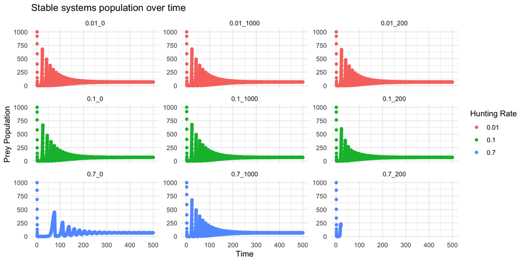

```r
# separate the list ids for plotting
systems_df <- bind_rows(results, .id = "id") %>%
  mutate(hunting_rate = as.factor(str_split(id, "_", simplify = TRUE)[,1]),
         min_pray = as.numeric(str_split(id, "_", simplify = TRUE)[,2]))

# did not end p
ggplot(data = systems_df, aes(x = time, y = prey, color = hunting_rate)) +
    geom_point() +
    facet_wrap(~id, scales = "free_y") +
    theme_minimal() +
    labs(title = "Stable systems population over time",
         x = "Time",
         y = "Prey Population",
         color = "Hunting Rate")
```

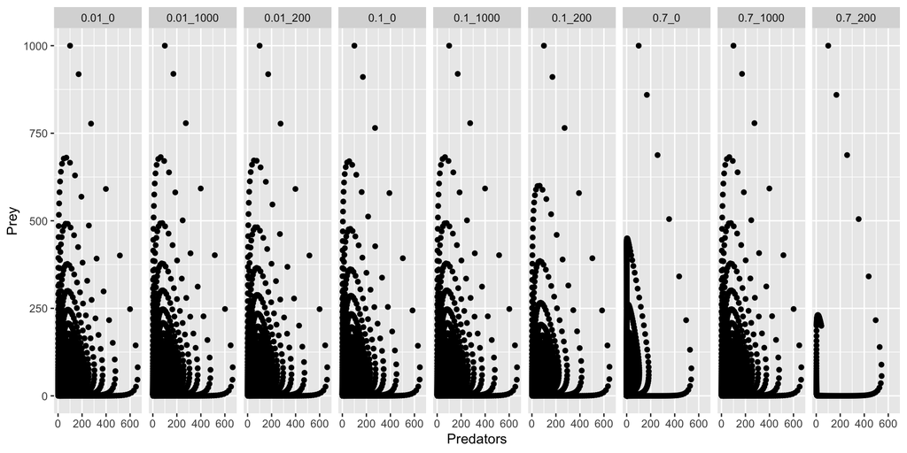

```r
# relationship between predator and prey graphs under the different hunting scenarios.
ggplot(systems_df, aes(pred, prey))+geom_point()+labs(y="Prey",x="Predators") + facet_grid(~id)
```

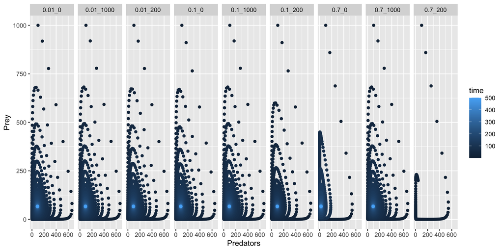

```r
ggplot(as.data.frame(systems_df), aes(pred, prey, col=time))+geom_point()+labs(y="Prey",x="Predators") + facet_grid(~id)
```

A key challenge is how you might want to define stability? Its up to you but you will need to write a sentence to explain why you chose the measure that you did. It could be something as simple as maintaining a population above some value 50 years into the future.

```r
# initialize stable systems list
stable_systems = list()

# extract results that have the desired stability criteria
for (name in names(results)) {
    df = results[[name]]
    final_populations = df[(nrow(df)-48):nrow(df),]
    if (all(final_populations$prey >= 50) && all(final_populations$pred >= 50)) {
        stable_systems[[name]] = final_populations
    }
}
```

```r
all_stable <- bind_rows(stable_systems, .id = "hunting_min")

# show all scenarios which eventually resulted in a stable population
unique(all_stable$hunting_min)
```

```
## [1] "0.01_0"    "0.01_200"  "0.01_1000" "0.1_0"     "0.1_200"   "0.1_1000"
## [7] "0.7_1000"
```

It’s also up to you how you “explore” hunting - you can simply try different values or do it more formally by running your model across a range of values

**Based on our results, we would recommend an hunting level below 70% of the population, as stability was not achieved for all minimum population levels with this hunting rate.**

Submit the Rmarkdown that documents your exploration (e.g how you tested different hunting level and how you defined a stability metric) and provides you estimated sustainable hunting level.